# Speed-acc-adult Drift Diffusion Analysis (DDM)

Kyle MacDonald

11/4/2016

## Setup

Read data.

## Plot RT histograms of guesses and valid responses.

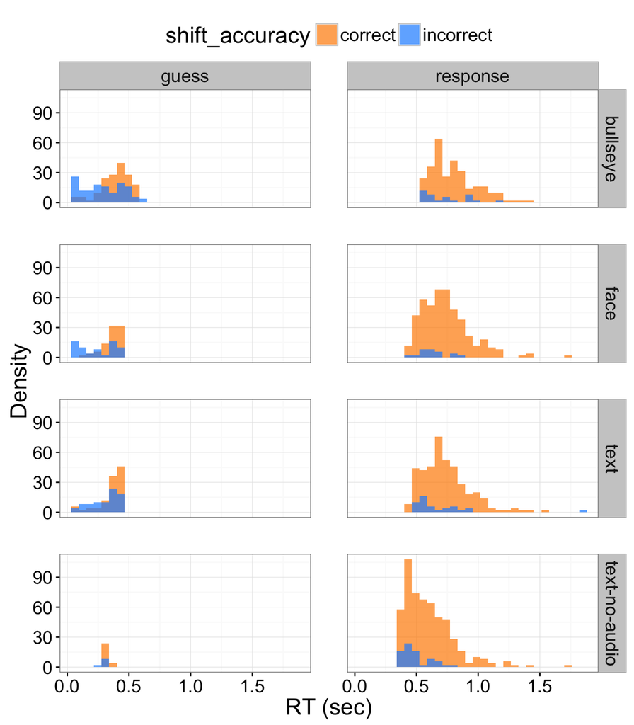

Make a table of number of “good” correct/incorrect shifts for each condition.

| condition | shift_accuracy | n |
| --- | --- | --- |
| bullseye | correct | 298 |
| bullseye | incorrect | 42 |
| face | correct | 464 |
| face | incorrect | 32 |
| text | correct | 412 |
| text | incorrect | 52 |
| text-no-audio | correct | 552 |
| text-no-audio | incorrect | 76 |

## Drift Diffusion Analysis

Workflow taken from Nordmeyer et al. (2016). The goal is to estimate parameters separately for each participant and then we aggregate across participants to get means & confidence intervals on the parameters.

The parameters of the drift drift diffusion model are:

- $\alpha$ = boundary separation: speed-accuracy tradeoff (higher values mean higher accuracy)
- $\beta$ = initial bias
- $\delta$ = drift rate: speed of information processing (close to zero means ambiguous information)
- $\tau$ = nondecision time: motor response time

Fit DDM for each participant and each condition.

Munge params to remove values +/- 2sd from the mean.

Boxplot for parameter values by condition:

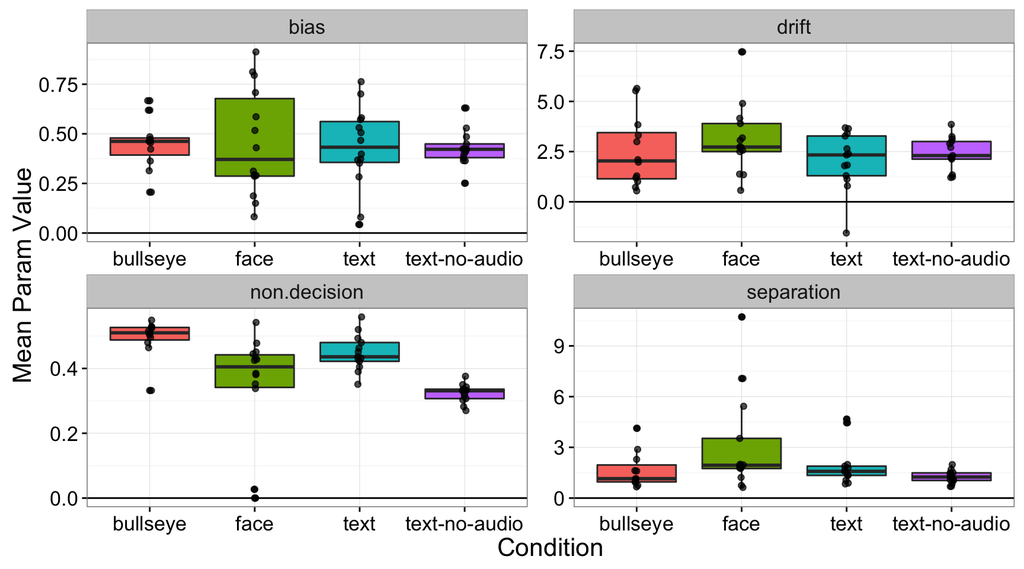

This analysis is exploratory since we do not have predictions about what these parameter estimates will look like after filtering out the fast guesses that we flagged using the EWMA model.